# PAC2

Carles M. Bosch Herrera

28/5/2020

## Índice

1. Entorno de trabajo y lectura de ficheros
2. Elección de datos de cada grupo de targets
3. Extracción aleatoriade muestras de cada grupo
4. Coincidencias con el archivo counts.csv
5. Packages
6. Lectura de datos y filtrado y eliminación de genes con contaje bajo
7. Counts to DGEList object
8. Quality Control
9. Diagrama de barras de los library sizes
10. Diagrama de cajas
11. Multidimensional scaling plots
12. Hierarchical clustering with heatmaps
13. Normalization for “composition bias”
14. Differential expression with limma-voom
15. Create the design matrix
16. Testing for differential expression
17. Annotation and saving the results
18. Volcano plot
19. Heatmap
20. Referencias

El objetivo de esta PEC es ilustrar el proceso de análisis de datos de ultrasecuenciación mediante la realización de un estudio, tal como se llevaria a cabo en una situación real. La PEC se basa en los datos suministrados de un estudio del que se debe extraer una muestra aleatoria con el fin de garantizar que cada conjunto de datos sea distinto.

# Entorno de trabajo y lectura de ficheros

Creamos el entorno de trabajo y leemos el fichero targets.csv

```r
setwd("C:/Users/CarlesM/Desktop/pac2")
getwd()
```

```
## [1] "C:/Users/CarlesM/Desktop/pac2"
```

```r
targets<- read.csv2(file.path("./data", "targets.csv"), head=T, sep=",")
head(targets,5)
```

```
##   Experiment SRA_Sample              Sample_Name Grupo_analisis body_site
## 1  SRX567480  SRS626942 GTEX-111CU-0226-SM-5GZXC              1   Thyroid
## 2  SRX615964  SRS644174 GTEX-111FC-1026-SM-5GZX1              1   Thyroid
## 3  SRX563960  SRS625636 GTEX-111VG-0526-SM-5N9BW              3   Thyroid
## 4  SRX564185  SRS625665 GTEX-111YS-0726-SM-5GZY8              1   Thyroid
## 5  SRX559141  SRS624025 GTEX-1122O-0226-SM-5N9DA              1   Thyroid
##          molecular_data_type    sex Group ShortName
## 1 Allele-Specific Expression   male   NIT 111CU_NIT
## 2              RNA Seq (NGS)   male   NIT 111FC_NIT
## 3              RNA Seq (NGS)   male   ELI 111VG_ELI
## 4 Allele-Specific Expression   male   NIT 111YS_NIT
## 5              RNA Seq (NGS) female   NIT 1122O_NIT
```

# Elección de datos de cada grupo de targets

Escogemos los datos de cada grupo del archivo targets

```r
datos_NIT<-targets[targets$Group=="NIT",]
head(datos_NIT,5)
```

```
##   Experiment SRA_Sample              Sample_Name Grupo_analisis body_site
## 1  SRX567480  SRS626942 GTEX-111CU-0226-SM-5GZXC              1   Thyroid
## 2  SRX615964  SRS644174 GTEX-111FC-1026-SM-5GZX1              1   Thyroid
## 4  SRX564185  SRS625665 GTEX-111YS-0726-SM-5GZY8              1   Thyroid
## 5  SRX559141  SRS624025 GTEX-1122O-0226-SM-5N9DA              1   Thyroid
## 6  SRX561718  SRS625313 GTEX-1128S-0126-SM-5H12S              1   Thyroid
##          molecular_data_type    sex Group ShortName
## 1 Allele-Specific Expression   male   NIT 111CU_NIT
## 2              RNA Seq (NGS)   male   NIT 111FC_NIT
## 4 Allele-Specific Expression   male   NIT 111YS_NIT
## 5              RNA Seq (NGS) female   NIT 1122O_NIT
## 6 Allele-Specific Expression female   NIT 1128S_NIT
```

```r
datos_ELI<-targets[targets$Group=="ELI",]
head(datos_ELI,5)
```

```
##     Experiment SRA_Sample              Sample_Name Grupo_analisis body_site
## 3    SRX563960  SRS625636 GTEX-111VG-0526-SM-5N9BW              3   Thyroid
## 29   SRX628009  SRS648152 GTEX-11NV4-0626-SM-5N9BR              3   Thyroid
## 40   SRX619829  SRS644736 GTEX-11XUK-0226-SM-5EQLW              3   Thyroid
## 100  SRX582762  SRS631169 GTEX-13NZ9-1126-SM-5MR37              3   Thyroid
## 119  SRX601511  SRS638114 GTEX-13QJC-0826-SM-5RQKC              3   Thyroid
##            molecular_data_type    sex Group ShortName
## 3                RNA Seq (NGS)   male   ELI 111VG_ELI
## 29               RNA Seq (NGS)   male   ELI 11NV4_ELI
## 40               RNA Seq (NGS) female   ELI 11XUK_ELI
## 100              RNA Seq (NGS)   male   ELI 13NZ9_ELI
## 119 Allele-Specific Expression female   ELI 13QJC_ELI
```

```r
datos_SFI<-targets[targets$Group=="SFI",]
head(datos_SFI,5)
```

```
##    Experiment SRA_Sample              Sample_Name Grupo_analisis body_site
## 9   SRX557750  SRS623875 GTEX-117YW-0126-SM-5EGGN              2   Thyroid
## 14  SRX578169  SRS629611 GTEX-11DXY-0426-SM-5H12R              2   Thyroid
## 21  SRX619524  SRS644703 GTEX-11EQ8-0826-SM-5N9FG              2   Thyroid
## 22  SRX558144  SRS623916 GTEX-11EQ9-0626-SM-5A5K1              2   Thyroid
## 23  SRX567902  SRS627040 GTEX-11GS4-0826-SM-5986J              2   Thyroid
##           molecular_data_type  sex Group ShortName
## 9               RNA Seq (NGS) male   SFI 117YW_SFI
## 14              RNA Seq (NGS) male   SFI 11DXY_SFI
## 21 Allele-Specific Expression male   SFI 11EQ8_SFI
## 22              RNA Seq (NGS) male   SFI 11EQ9_SFI
## 23              RNA Seq (NGS) male   SFI 11GS4_SFI
```

# Extracción aleatoria de muestras de cada grupo

Extraemos las 10 muestras aleatoriamente de cada grupo

```r
muestra.NIT = datos_NIT[sample(nrow(datos_NIT),10) , ]
muestra.SFI = datos_SFI[sample(nrow(datos_SFI),10) , ]
muestra.ELI = datos_ELI[sample(nrow(datos_ELI),10) , ]

muestra.NIT
```

```
##     Experiment SRA_Sample              Sample_Name Grupo_analisis body_site
## 268  SRX585167  SRS631757  GTEX-ZPU1-0426-SM-4WWCA              1   Thyroid
## 175  SRX199142  SRS333029  GTEX-QDVN-0626-SM-2I3FP              1   Thyroid
## 279  SRX584212  SRS631462  GTEX-ZVT3-0726-SM-5GICN              1   Thyroid
## 277  SRX615716  SRS644145  GTEX-ZV7C-0126-SM-57WDE              1   Thyroid
## 93   SRX580140  SRS629907 GTEX-13JVG-0926-SM-5IJE1              1   Thyroid
## 68   SRX571829  SRS627809 GTEX-131XH-0526-SM-5DUX7              1   Thyroid
## 27   SRX598448  SRS637651 GTEX-11NSD-0126-SM-5987F              1   Thyroid
## 204  SRX223447  SRS389961  GTEX-SJXC-0726-SM-2XCFJ              1   Thyroid
## 209  SRX221407  SRS389066  GTEX-T8EM-0226-SM-3DB7C              1   Thyroid
## 7    SRX588467  SRS633874 GTEX-113JC-0126-SM-5EGJW              1   Thyroid
##            molecular_data_type    sex Group ShortName
## 268 Allele-Specific Expression   male   NIT ZPU1-_NIT
## 175              RNA Seq (NGS)   male   NIT QDVN-_NIT
## 279 Allele-Specific Expression female   NIT ZVT3-_NIT
## 277              RNA Seq (NGS)   male   NIT ZV7C-_NIT
## 93  Allele-Specific Expression   male   NIT 13JVG_NIT
## 68  Allele-Specific Expression   male   NIT 131XH_NIT
## 27               RNA Seq (NGS)   male   NIT 11NSD_NIT
## 204              RNA Seq (NGS)   male   NIT SJXC-_NIT
## 209              RNA Seq (NGS)   male   NIT T8EM-_NIT
## 7                RNA Seq (NGS) female   NIT 113JC_NIT
```

```r
muestra.SFI
```

```
##     Experiment SRA_Sample              Sample_Name Grupo_analisis body_site
## 185  SRX203531  SRS374739  GTEX-R55E-0826-SM-2TC5M              2   Thyroid
## 184  SRX204008  SRS374961  GTEX-R55C-0626-SM-2TF4Q              2   Thyroid
## 83   SRX561460  SRS625222 GTEX-13FH7-0126-SM-5KLZ1              2   Thyroid
## 166  SRX198253  SRS333514  GTEX-P78B-0526-SM-2I5F7              2   Thyroid
## 59   SRX567279  SRS626844 GTEX-12ZZY-0826-SM-5EQMT              2   Thyroid
## 58   SRX601535  SRS638117 GTEX-12ZZX-1226-SM-5EGHS              2   Thyroid
## 188  SRX203696  SRS374817  GTEX-RM2N-0526-SM-2TF4N              2   Thyroid
## 49   SRX607261  SRS639479 GTEX-12BJ1-0426-SM-5FQSO              2   Thyroid
## 252  SRX630577  SRS648438  GTEX-YFCO-0326-SM-4W1ZP              2   Thyroid
## 203  SRX223043  SRS389833  GTEX-SIU8-0626-SM-2XCDN              2   Thyroid
##            molecular_data_type    sex Group ShortName
## 185 Allele-Specific Expression   male   SFI R55E-_SFI
## 184 Allele-Specific Expression   male   SFI R55C-_SFI
## 83  Allele-Specific Expression female   SFI 13FH7_SFI
## 166 Allele-Specific Expression female   SFI P78B-_SFI
## 59               RNA Seq (NGS)   male   SFI 12ZZY_SFI
## 58               RNA Seq (NGS) female   SFI 12ZZX_SFI
## 188              RNA Seq (NGS)   male   SFI RM2N-_SFI
## 49  Allele-Specific Expression   male   SFI 12BJ1_SFI
## 252 Allele-Specific Expression   male   SFI YFCO-_SFI
## 203 Allele-Specific Expression   male   SFI SIU8-_SFI
```

```r
muestra.ELI
```

```
##     Experiment SRA_Sample              Sample_Name Grupo_analisis body_site
## 147  SRX607358  SRS639491 GTEX-14AS3-0226-SM-5Q5B6              3   Thyroid
## 211  SRX222429  SRS389623  GTEX-TMMY-0826-SM-33HB9              3   Thyroid
## 100  SRX582762  SRS631169 GTEX-13NZ9-1126-SM-5MR37              3   Thyroid
## 186  SRX204036  SRS374975  GTEX-R55G-0726-SM-2TC6J              3   Thyroid
## 29   SRX628009  SRS648152 GTEX-11NV4-0626-SM-5N9BR              3   Thyroid
## 3    SRX563960  SRS625636 GTEX-111VG-0526-SM-5N9BW              3   Thyroid
## 290  SRX568364  SRS627095  GTEX-ZYY3-1926-SM-5GZXS              3   Thyroid
## 40   SRX619829  SRS644736 GTEX-11XUK-0226-SM-5EQLW              3   Thyroid
## 251  SRX615373  SRS644099  GTEX-YFC4-2626-SM-5P9FQ              3   Thyroid
## 167  SRX199272  SRS333099  GTEX-PLZ4-1226-SM-2I5FE              3   Thyroid
##            molecular_data_type    sex Group ShortName
## 147              RNA Seq (NGS) female   ELI 14AS3_ELI
## 211 Allele-Specific Expression female   ELI TMMY-_ELI
## 100              RNA Seq (NGS)   male   ELI 13NZ9_ELI
## 186              RNA Seq (NGS) female   ELI R55G-_ELI
## 29               RNA Seq (NGS)   male   ELI 11NV4_ELI
## 3                RNA Seq (NGS)   male   ELI 111VG_ELI
## 290 Allele-Specific Expression female   ELI ZYY3-_ELI
## 40               RNA Seq (NGS) female   ELI 11XUK_ELI
## 251 Allele-Specific Expression female   ELI YFC4-_ELI
## 167              RNA Seq (NGS) female   ELI PLZ4-_ELI
```

# Coincidencias con el archivo counts.csv

```r
scounts<- read.csv2(file.path("./data", "selectcounts.csv"), head=T, sep=";")
str(scounts)
```

```
## 'data.frame':    56202 obs. of  31 variables:
##  $ X                       : Factor w/ 56202 levels "ENSG00000000003.10",..: 26352 28704 39144 36095 53325 37828 16363 36388 33329 36152 ...
##  $ GTEX.111VG.0526.SM.5N9BW: int  1 474 1 0 1 1 0 3 7 427 ...
##  $ GTEX.11EM3.0126.SM.5985K: int  2 669 2 1 1 1 0 3 20 791 ...
##  $ GTEX.11EMC.0226.SM.5EGLP: int  5 786 0 0 0 1 0 10 8 553 ...
##  $ GTEX.11NSD.0126.SM.5987F: int  0 408 1 0 0 0 2 11 19 800 ...
##  $ GTEX.11NV4.0626.SM.5N9BR: int  3 1301 1 0 0 1 0 5 7 1132 ...
##  $ GTEX.11O72.2326.SM.5BC7H: int  0 633 2 1 0 1 1 14 11 1075 ...
##  $ GTEX.12WSG.0226.SM.5EGIF: int  3 369 1 3 1 2 2 3 10 235 ...
##  $ GTEX.139UW.0126.SM.5KM1B: int  2 430 0 0 0 0 0 9 9 679 ...
##  $ GTEX.13NZ9.1126.SM.5MR37: int  0 1002 1 0 0 1 0 15 19 602 ...
##  $ GTEX.13O1R.0826.SM.5J2MB: int  3 460 0 1 2 0 1 7 12 279 ...
##  $ GTEX.13OVG.0226.SM.5LU93: int  4 719 2 1 2 2 1 6 14 1064 ...
##  $ GTEX.13QJC.0826.SM.5RQKC: int  0 825 1 0 0 1 1 10 21 853 ...
##  $ GTEX.13U4I.0526.SM.5LU59: int  2 636 0 0 0 0 0 8 13 606 ...
```

[output cut: 17 more lines]

# Packages

Ahora tendremos que cargar los paquetes que necesitaremos

```r
library(edgeR)
```

```r
library (limma)
library(Glimma)
library(gplots)
library(org.Mm.eg.db)
library(org.Hs.eg.db)
library(RColorBrewer)
library(DESeq2)
```

# Lectura de datos y filtrado y eliminacion de genes con contajes bajos

Los genes con recuentos muy bajos en todas las bibliotecas proporcionan poca evidencia en la expresión diferencial e interfieren con algunas de las aproximaciones estadísticas que se utilizan más adelante dentro del pipeleine del análisis.

Asimismo añaden “ruido”" en el ajuste por múltiple testing mediante FDR, reduciendo “potencia estadística” en la detección de genes expresados diferencialmente (como ya hemos discutido en debates anteriores).

Estos genes deben filtrarse antes de un análisis posterior.

Hay diferentes maneras de filtrar genes poco expresados. En este caso optamos por retener los genes si se expresan en un conteo por millón (CPM) por encima de 0.5 en al menos dos muestras.

Utilizaremos la función cpm del package edgeR para generar los valores de CPM y luego filtrar. Hay que tener presente que al convertir a CPM estamos normalizando segun el “Sequencing depth” de cada muestra.

Nota: Secuencing depth es comúnmente un término usado para la secuenciación del genoma o del exoma y significa el número de lecturas que cubren cada posición.

```r
 rownames(scounts)<-scounts[,1]
 scounts<-scounts[,-(1)]
 library(edgeR)
 dgeList_counts<-DGEList(scounts)
 counts_cpm<-cpm(dgeList_counts,log=TRUE)
 head(counts_cpm)
```

```
##                   GTEX.111VG.0526.SM.5N9BW GTEX.11EM3.0126.SM.5985K
## ENSG00000223972.4                -4.162194                -3.890311
## ENSG00000227232.4                 3.188591                 3.367278
## ENSG00000243485.2                -4.162194                -3.890311
## ENSG00000237613.2                -4.768198                -4.263485
## ENSG00000268020.2                -4.162194                -4.263485
## ENSG00000240361.1                -4.162194                -4.263485
##                   GTEX.11EMC.0226.SM.5EGLP GTEX.11NSD.0126.SM.5987F
## ENSG00000223972.4                -3.149473                -4.768198
## ENSG00000227232.4                 3.583036                 2.973675
## ENSG00000243485.2                -4.768198                -4.162034
## ENSG00000237613.2                -4.768198                -4.768198
## ENSG00000268020.2                -4.768198                -4.768198
## ENSG00000240361.1                -4.268205                -4.768198
##                   GTEX.11NV4.0626.SM.5N9BR GTEX.11O72.2326.SM.5BC7H
## ENSG00000223972.4                -3.404865                -4.768198
## ENSG00000227232.4                 4.647684                 3.214006
## ENSG00000243485.2                -4.160086                -3.923594
## ENSG00000237613.2                -4.768198                -4.284952
## ENSG00000268020.2                -4.768198                -4.768198
## ENSG00000240361.1                -4.160086                -4.284952
##                   GTEX.12WSG.0226.SM.5EGIF GTEX.139UW.0126.SM.5KM1B
## ENSG00000223972.4                -3.128109                -3.676954
## ENSG00000227232.4                 3.261766                 3.162977
## ENSG00000243485.2                -3.997905                -4.768198
## ENSG00000237613.2                -3.128109                -4.768198
## ENSG00000268020.2                -3.997905                -4.768198
## ENSG00000240361.1                -3.498427                -4.768198
##                   GTEX.13NZ9.1126.SM.5MR37 GTEX.13O1R.0826.SM.5J2MB
## ENSG00000223972.4                -4.768198                -3.538156
## ENSG00000227232.4                 4.030623                 2.927702
## ENSG00000243485.2                -4.238656                -4.768198
## ENSG00000237613.2                -4.768198                -4.233559
## ENSG00000268020.2                -4.768198                -3.844358
## ENSG00000240361.1                -4.238656                -4.768198
##                   GTEX.13OVG.0226.SM.5LU93 GTEX.13QJC.0826.SM.5RQKC
## ENSG00000223972.4                -3.039814                -4.768198
## ENSG00000227232.4                 3.935232                 4.081484
## ENSG00000243485.2                -3.659318                -4.128516
## ENSG00000237613.2                -4.109743                -4.768198
```

[output cut: 50 more lines]

```
## ENSG00000240361.1               -4.350836               -4.315807
##                   GTEX.Z9EW.0226.SM.5CVM7 GTEX.ZLV1.0126.SM.4WWBZ
## ENSG00000223972.4               -3.310837               -3.780305
## ENSG00000227232.4                3.270219                3.640098
## ENSG00000243485.2               -3.654472               -3.780305
## ENSG00000237613.2               -3.654472               -3.199401
## ENSG00000268020.2               -4.768198               -4.768198
## ENSG00000240361.1               -4.106431               -3.780305
##                   GTEX.ZYVF.1126.SM.5E458 GTEX.ZYY3.1926.SM.5GZXS
## ENSG00000223972.4               -3.657650               -2.649670
## ENSG00000227232.4                4.158799                4.360455
## ENSG00000243485.2               -4.108604               -4.129351
## ENSG00000237613.2               -3.037644               -3.688108
## ENSG00000268020.2               -4.108604               -4.768198
## ENSG00000240361.1               -4.108604               -4.129351
```

```r
# Which values in myCPM are greater than 0.5?
thresh <- counts_cpm > 0.5
# This produces a logical matrix with TRUEs and FALSEs
head(thresh)
```

```
##                   GTEX.111VG.0526.SM.5N9BW GTEX.11EM3.0126.SM.5985K
## ENSG00000223972.4                    FALSE                    FALSE
## ENSG00000227232.4                     TRUE                     TRUE
## ENSG00000243485.2                    FALSE                    FALSE
## ENSG00000237613.2                    FALSE                    FALSE
## ENSG00000268020.2                    FALSE                    FALSE
## ENSG00000240361.1                    FALSE                    FALSE
##                   GTEX.11EMC.0226.SM.5EGLP GTEX.11NSD.0126.SM.5987F
## ENSG00000223972.4                    FALSE                    FALSE
## ENSG00000227232.4                     TRUE                     TRUE
## ENSG00000243485.2                    FALSE                    FALSE
## ENSG00000237613.2                    FALSE                    FALSE
## ENSG00000268020.2                    FALSE                    FALSE
## ENSG00000240361.1                    FALSE                    FALSE
##                   GTEX.11NV4.0626.SM.5N9BR GTEX.11O72.2326.SM.5BC7H
## ENSG00000223972.4                    FALSE                    FALSE
## ENSG00000227232.4                     TRUE                     TRUE
## ENSG00000243485.2                    FALSE                    FALSE
## ENSG00000237613.2                    FALSE                    FALSE
## ENSG00000268020.2                    FALSE                    FALSE
## ENSG00000240361.1                    FALSE                    FALSE
##                   GTEX.12WSG.0226.SM.5EGIF GTEX.139UW.0126.SM.5KM1B
## ENSG00000223972.4                    FALSE                    FALSE
## ENSG00000227232.4                     TRUE                     TRUE
## ENSG00000243485.2                    FALSE                    FALSE
## ENSG00000237613.2                    FALSE                    FALSE
## ENSG00000268020.2                    FALSE                    FALSE
## ENSG00000240361.1                    FALSE                    FALSE
##                   GTEX.13NZ9.1126.SM.5MR37 GTEX.13O1R.0826.SM.5J2MB
## ENSG00000223972.4                    FALSE                    FALSE
## ENSG00000227232.4                     TRUE                     TRUE
## ENSG00000243485.2                    FALSE                    FALSE
## ENSG00000237613.2                    FALSE                    FALSE
## ENSG00000268020.2                    FALSE                    FALSE
## ENSG00000240361.1                    FALSE                    FALSE
##                   GTEX.13OVG.0226.SM.5LU93 GTEX.13QJC.0826.SM.5RQKC
## ENSG00000223972.4                    FALSE                    FALSE
## ENSG00000227232.4                     TRUE                     TRUE
## ENSG00000243485.2                    FALSE                    FALSE
## ENSG00000237613.2                    FALSE                    FALSE
```

[output cut: 50 more lines]

```
## ENSG00000240361.1                   FALSE                   FALSE
##                   GTEX.Z9EW.0226.SM.5CVM7 GTEX.ZLV1.0126.SM.4WWBZ
## ENSG00000223972.4                   FALSE                   FALSE
## ENSG00000227232.4                    TRUE                    TRUE
## ENSG00000243485.2                   FALSE                   FALSE
## ENSG00000237613.2                   FALSE                   FALSE
## ENSG00000268020.2                   FALSE                   FALSE
## ENSG00000240361.1                   FALSE                   FALSE
##                   GTEX.ZYVF.1126.SM.5E458 GTEX.ZYY3.1926.SM.5GZXS
## ENSG00000223972.4                   FALSE                   FALSE
## ENSG00000227232.4                    TRUE                    TRUE
## ENSG00000243485.2                   FALSE                   FALSE
## ENSG00000237613.2                   FALSE                   FALSE
## ENSG00000268020.2                   FALSE                   FALSE
## ENSG00000240361.1                   FALSE                   FALSE
```

```r
# Summary of how many TRUEs there are in each row
# There are 13142 genes that have TRUEs in all 30 samples.
table(rowSums(thresh))
```

```
##
##     0     1     2     3     4     5     6     7     8     9    10    11    12
## 37003   825   439   332   294   244   211   174   164   180   140   154   125
##    13    14    15    16    17    18    19    20    21    22    23    24    25
##   130   139   136   142   125   124   121   113   138   108   117   148   161
##    26    27    28    29    30
##   174   206   256   437 13142
```

```r
# we would like to keep genes that have at least 2 TRUES in each row of thresh
keep <- rowSums(thresh) >= 2
# Subset the rows of countdata to keep the more highly expressed genes
counts.keep <- scounts[keep,]
summary(keep)
```

```
##    Mode   FALSE    TRUE
## logical   37828   18374
```

```r
dim(counts.keep)
```

```
## [1] 18374    30
```

Como regla general, se puede elegir un buen umbral identificando el CPM que corresponde a un recuento de 10.

Se debe filtrar a partir de el objeto CPM en lugar de filtrar los counting data (recuentos directamente), ya que este último no tiene en cuenta las diferencias en los tamaños de biblioteca (library sizes) entre las muestras.

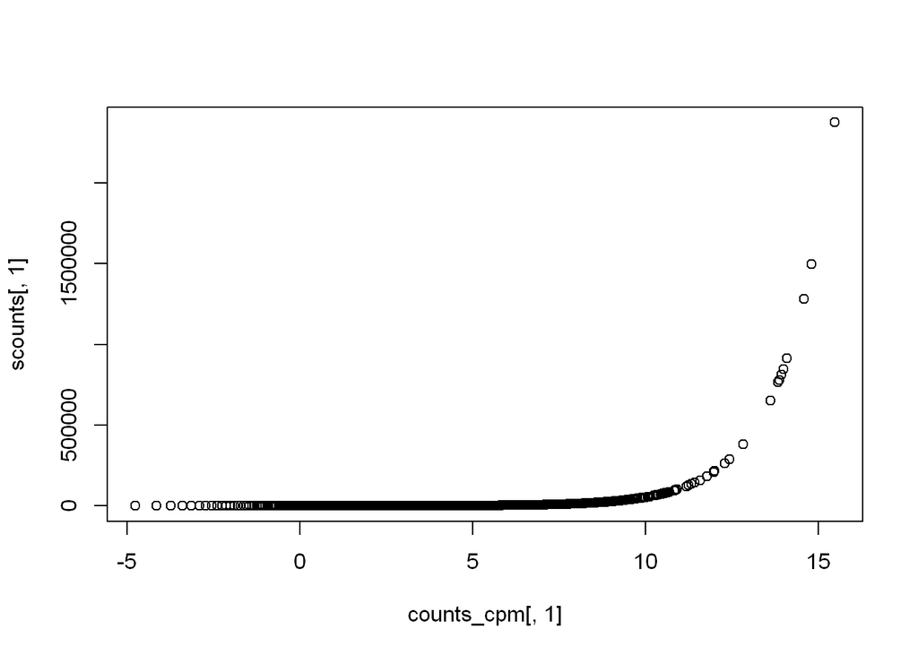

```r
# Let's have a look and see whether our threshold of 0.5 does indeed correspond to a count of about 10-15
# We will look at the first sample
plot(counts_cpm[,1],scounts[,1])
```

# Counts to DGEList object

A continuación crearemos un objeto DGEList. Este es un objeto utilizado por edgeR para almacenar datos de recuento

```r
y <- DGEList(counts.keep)
# have a look at y
y
```

```
## An object of class "DGEList"
## $counts
##                   GTEX.111VG.0526.SM.5N9BW GTEX.11EM3.0126.SM.5985K
## ENSG00000227232.4                      474                      669
## ENSG00000237683.5                      427                      791
## ENSG00000241860.2                       92                       68
## ENSG00000228463.4                        9                        9
## ENSG00000225972.1                       87                      155
##                   GTEX.11EMC.0226.SM.5EGLP GTEX.11NSD.0126.SM.5987F
## ENSG00000227232.4                      786                      408
## ENSG00000237683.5                      553                      800
## ENSG00000241860.2                      107                       29
## ENSG00000228463.4                       57                       51
## ENSG00000225972.1                       82                      135
##                   GTEX.11NV4.0626.SM.5N9BR GTEX.11O72.2326.SM.5BC7H
## ENSG00000227232.4                     1301                      633
## ENSG00000237683.5                     1132                     1075
## ENSG00000241860.2                       46                       82
## ENSG00000228463.4                       92                       16
## ENSG00000225972.1                       23                       57
##                   GTEX.12WSG.0226.SM.5EGIF GTEX.139UW.0126.SM.5KM1B
## ENSG00000227232.4                      369                      430
## ENSG00000237683.5                      235                      679
## ENSG00000241860.2                       21                       95
## ENSG00000228463.4                        6                       26
## ENSG00000225972.1                      101                       54
##                   GTEX.13NZ9.1126.SM.5MR37 GTEX.13O1R.0826.SM.5J2MB
## ENSG00000227232.4                     1002                      460
## ENSG00000237683.5                      602                      279
## ENSG00000241860.2                       96                       41
## ENSG00000228463.4                       39                       16
## ENSG00000225972.1                     4678                       99
##                   GTEX.13OVG.0226.SM.5LU93 GTEX.13QJC.0826.SM.5RQKC
## ENSG00000227232.4                      719                      825
## ENSG00000237683.5                     1064                      853
## ENSG00000241860.2                       91                       94
## ENSG00000228463.4                       41                       98
## ENSG00000225972.1                       64                       55
##                   GTEX.13U4I.0526.SM.5LU59 GTEX.14ABY.0926.SM.5Q5DY
## ENSG00000227232.4                      636                      775
```

[output cut: 47 more lines]

```
## ENSG00000227232.4                     838                    1003
## ENSG00000237683.5                    1212                     960
## ENSG00000241860.2                      89                      59
## ENSG00000228463.4                      21                      26
## ENSG00000225972.1                      51                      66
## 18369 more rows ...
##
## $samples
##                          group lib.size norm.factors
## GTEX.111VG.0526.SM.5N9BW     1 52085501            1
## GTEX.11EM3.0126.SM.5985K     1 64954617            1
## GTEX.11EMC.0226.SM.5EGLP     1 65673287            1
## GTEX.11NSD.0126.SM.5987F     1 52084492            1
## GTEX.11NV4.0626.SM.5N9BR     1 51837308            1
## 25 more rows ...
```

```r
# See what slots are stored in y
names(y)
```

```
## [1] "counts"  "samples"
```

```r
# Library size information is stored in the samples slot
y$samples
```

```
##                          group lib.size norm.factors
## GTEX.111VG.0526.SM.5N9BW     1 52085501            1
## GTEX.11EM3.0126.SM.5985K     1 64954617            1
## GTEX.11EMC.0226.SM.5EGLP     1 65673287            1
## GTEX.11NSD.0126.SM.5987F     1 52084492            1
## GTEX.11NV4.0626.SM.5N9BR     1 51837308            1
## GTEX.11O72.2326.SM.5BC7H     1 68388840            1
## GTEX.12WSG.0226.SM.5EGIF     1 38526920            1
## GTEX.139UW.0126.SM.5KM1B     1 48121274            1
## GTEX.13NZ9.1126.SM.5MR37     1 61301417            1
## GTEX.13O1R.0826.SM.5J2MB     1 60635354            1
## GTEX.13OVG.0226.SM.5LU93     1 47021443            1
## GTEX.13QJC.0826.SM.5RQKC     1 48725791            1
## GTEX.13U4I.0526.SM.5LU59     1 45294109            1
## GTEX.14ABY.0926.SM.5Q5DY     1 64593320            1
## GTEX.14AS3.0226.SM.5Q5B6     1 41908407            1
## GTEX.14BMU.0226.SM.5S2QA     1 44406229            1
## GTEX.PWN1.2626.SM.2I3FH      1 39644072            1
## GTEX.S7SE.0726.SM.2XCD7      1 41928929            1
## GTEX.T5JW.1226.SM.3GACY      1 46317315            1
## GTEX.WYVS.0326.SM.3NM9V      1 76564730            1
## GTEX.XBED.0126.SM.47JY7      1 47027068            1
## GTEX.XMK1.0626.SM.4B65A      1 52878007            1
## GTEX.Y5V6.0526.SM.4VBRV      1 68606086            1
## GTEX.YEC4.0626.SM.5CVLU      1 50583432            1
## GTEX.YFC4.2626.SM.5P9FQ      1 80995956            1
## GTEX.YJ89.0726.SM.5P9F7      1 73817346            1
## GTEX.Z9EW.0226.SM.5CVM7      1 46741531            1
## GTEX.ZLV1.0126.SM.4WWBZ      1 55313069            1
## GTEX.ZYVF.1126.SM.5E458      1 46918338            1
## GTEX.ZYY3.1926.SM.5GZXS      1 48818257            1
```

# Quality control

Ahora que hemos eliminado los genes de baja expresión y hemos almacenado nuestros conteos en un objeto DGEList, vamos a llevar a cabo algunos gráficos que nos permitan realizar un pequeño informe de los mismos (Quality control).

## Library sizes and distribution plots

Primero, podemos verificar cuántas lecturas tenemos para cada muestra en el objeto creado (counting data)

```r
y$samples$lib.size
```

```
##  [1] 52085501 64954617 65673287 52084492 51837308 68388840 38526920 48121274
##  [9] 61301417 60635354 47021443 48725791 45294109 64593320 41908407 44406229
## [17] 39644072 41928929 46317315 76564730 47027068 52878007 68606086 50583432
## [25] 80995956 73817346 46741531 55313069 46918338 48818257
```

# Diagrama de barras de los library sizes

También podemos plotear a partir de un diagrama de barras de los “library sizes”" para ver si hay discrepancias importantes entre las muestras

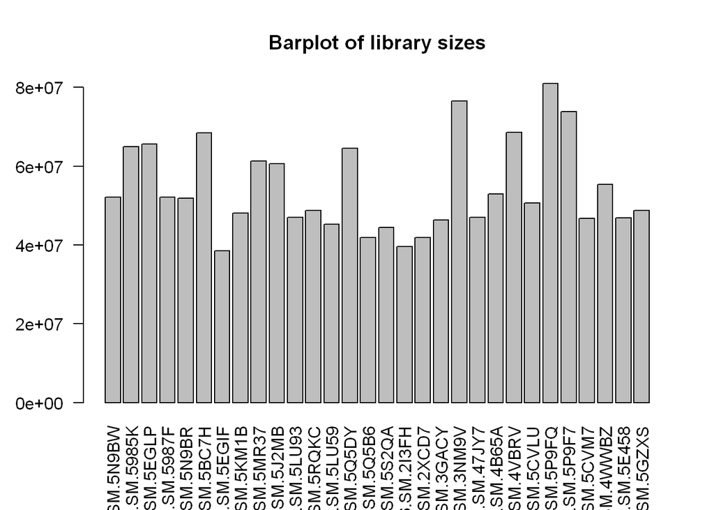

```r
# The names argument tells the barplot to use the sample names on the x-axis
# The las argument rotates the axis names
barplot(y$samples$lib.size,names=colnames(y),las=2)
# Add a title to the plot
title("Barplot of library sizes")
```

Los “counting data” (datos de recuento) no se distribuyen segun una Distribución Normal, por lo que si queremos examinar las distribuciones de los recuentos sin procesar, utilizaremos Boxplots para verificar la distribución de los recuentos de lectura en escala log2.

Podemos usar la función cpm para obtener recuentos de log2 por millón, corregidos por los library sizes (tamaños de biblioteca). La función cpm también incorpora una pequeña “modificación” para evitar el problema asociado al logaritmo de valores de cero.

# 10, Diagrama de cajas

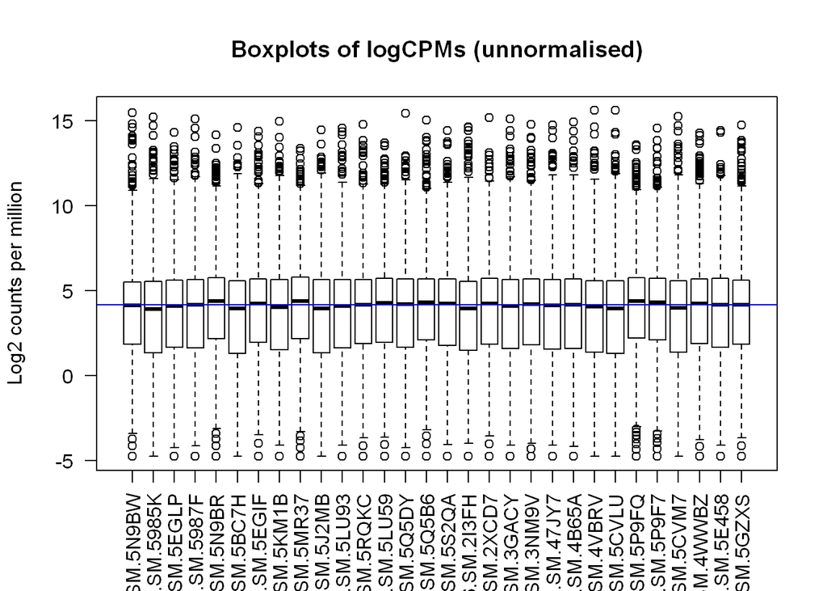

```r
# Get log2 counts per million
logcounts <- cpm(y,log=TRUE)
# Check distributions of samples using boxplots
boxplot(logcounts, xlab="", ylab="Log2 counts per million",las=2)
# Let's add a blue horizontal line that corresponds to the median logCPM
abline(h=median(logcounts),col="blue")
title("Boxplots of logCPMs (unnormalised)")
```

De los boxplots, vemos que, en general, las distribuciones del counting data no son idénticas, pero tampoco son muy diferentes.

Si una muestra está realmente muy por encima o por debajo de la línea horizontal azul, es posible que tengamos que investigar más esa muestra.

# Multidimensional scaling plots

Uno de los gráficos más importante en el Quality control es el MDS. Un MDSplot es un gráfico, que nos permite “visualizar” variabilidad en los datos. Si su experimento está bien “controlado”" y funcionó bien, lo que esperamos ver es que las principales fuentes de variación en los datos sean los tratamientos / grupos que nos interesan.

También nos puede ayudar en “la visualización de valores atípicos. Podemos usar la función plotMDS para crear el diagrama de MDS.

## Diagrama de MDS

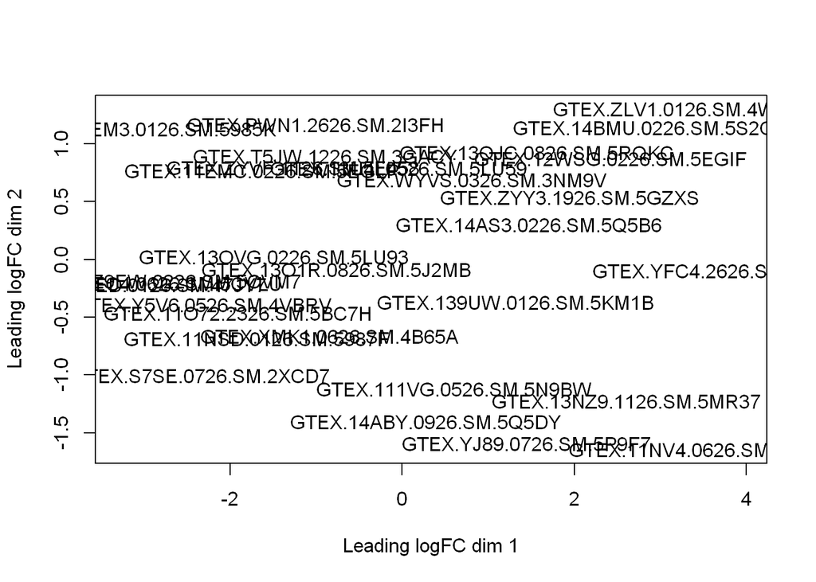

```r
plotMDS(y)
```

La verdad es que no se ve muy bien :(

# Hierarchical clustering with heatmaps

Podemos complementar la visualización de los datos con la función heapmap.2 que nos permite+iria obtener la representación del cluster jerárquico de las muestras, en concreto, en este ejemplo, se grafica (a partir del método average) la matriz de distancias euclídeas del logCPM (objeto logcounts) para los 500 genes más variables. El diagrama del heatmap se representará en el último apartado.

```r
# We estimate the variance for each row in the logcounts matrix
var_genes <- apply(logcounts, 1, var)
head(var_genes)
```

```
## ENSG00000227232.4 ENSG00000237683.5 ENSG00000241860.2 ENSG00000228463.4
##         0.2566127         0.5135544         0.2989137         1.2509434
## ENSG00000225972.1 ENSG00000225630.1
##         1.8498334         0.7374741
```

```r
# Get the gene names for the top 500 most variable genes
select_var <- names(sort(var_genes, decreasing=TRUE))[1:500]
head(select_var)
```

```
## [1] "ENSG00000229807.5"  "ENSG00000110680.8"  "ENSG00000012817.11"
## [4] "ENSG00000114374.8"  "ENSG00000131002.7"  "ENSG00000129824.11"
```

```r
# Subset logcounts matrix
highly_variable_lcpm <- logcounts[select_var,]
dim(highly_variable_lcpm)
```

```
## [1] 500  30
```

```r
head(highly_variable_lcpm)
```

```
##                    GTEX.111VG.0526.SM.5N9BW GTEX.11EM3.0126.SM.5985K
## ENSG00000229807.5                 -2.718176                9.3032207
## ENSG00000110680.8                 -1.622558               -0.5821209
## ENSG00000012817.11                 7.263680               -1.8206317
## ENSG00000114374.8                  6.060782               -2.1745202
## ENSG00000131002.7                  6.654994               -2.7904720
## ENSG00000129824.11                 7.462084               -0.8761533
##                    GTEX.11EMC.0226.SM.5EGLP GTEX.11NSD.0126.SM.5987F
## ENSG00000229807.5                 8.8746914                -2.128050
## ENSG00000110680.8                 7.7763875                -2.718155
## ENSG00000012817.11               -2.8022915                 7.275198
## ENSG00000114374.8                -2.1877475                 6.507863
## ENSG00000131002.7                -2.6566599                 6.091193
## ENSG00000129824.11               -0.8909509                 7.677126
##                    GTEX.11NV4.0626.SM.5N9BR GTEX.11O72.2326.SM.5BC7H
## ENSG00000229807.5                 -2.712949                -1.602891
## ENSG00000110680.8                 -2.712949                 3.397195
## ENSG00000012817.11                 7.871551                 6.678998
## ENSG00000114374.8                  6.485204                 6.132382
## ENSG00000131002.7                  7.409647                 5.157281
## ENSG00000129824.11                 7.852049                 7.846139
##                    GTEX.12WSG.0226.SM.5EGIF GTEX.139UW.0126.SM.5KM1B
## ENSG00000229807.5                 9.4114330                -2.300322
## ENSG00000110680.8                -1.8869714                -1.805201
## ENSG00000012817.11               -3.9947683                 6.975253
## ENSG00000114374.8                -3.4951997                 6.810346
## ENSG00000131002.7                -3.1248326                 6.436111
## ENSG00000129824.11               -0.6000913                 7.553627
##                    GTEX.13NZ9.1126.SM.5MR37 GTEX.13O1R.0826.SM.5J2MB
## ENSG00000229807.5                 -3.848986                -1.384193
## ENSG00000110680.8                 -2.445467                 9.692514
## ENSG00000012817.11                 7.977681                 6.677879
## ENSG00000114374.8                  6.397054                 6.536891
## ENSG00000131002.7                  6.683575                 6.145760
## ENSG00000129824.11                 7.784346                 7.762029
##                    GTEX.13OVG.0226.SM.5LU93 GTEX.13QJC.0826.SM.5RQKC
## ENSG00000229807.5                 -2.003235                 9.434566
## ENSG00000110680.8                 -3.036955                -1.299790
## ENSG00000012817.11                 7.366544                -3.072626
## ENSG00000114374.8                  6.597902                -4.125467
```

[output cut: 50 more lines]

```
## ENSG00000129824.11               -2.641747                7.947008
##                    GTEX.Z9EW.0226.SM.5CVM7 GTEX.ZLV1.0126.SM.4WWBZ
## ENSG00000229807.5               -0.1640095                9.459529
## ENSG00000110680.8                9.9851052               -2.085349
## ENSG00000012817.11               7.2177655               -4.765281
## ENSG00000114374.8                6.2123057               -2.975218
## ENSG00000131002.7                5.9585426               -3.777364
## ENSG00000129824.11               7.5016355               -3.196451
##                    GTEX.ZYVF.1126.SM.5E458 GTEX.ZYY3.1926.SM.5GZXS
## ENSG00000229807.5              9.848223161               8.5286664
## ENSG00000110680.8             -2.270345829               3.7565253
## ENSG00000012817.11            -0.983729159              -1.1634167
## ENSG00000114374.8             -3.654745620              -2.4726482
## ENSG00000131002.7             -3.311691623              -2.4726482
## ENSG00000129824.11            -0.005949852              -0.7615973
```

# Normalization for “composition bias”

El procesos de normalización denominado TMM se realiza para eliminar los sesgos de composición (bias compostion) entre las bibliotecas.

Este método genera un conjunto de factores de normalización, donde el producto de estos factores y los tamaños de la biblioteca (library sizes) definen el tamaño efectivo de la biblioteca (effective library size).

La función calcNormFactors calcula los factores de normalización entre bibliotecas.

```r
# Apply normalisation to DGEList object
y <- calcNormFactors(y)
head(y)
```

```
## An object of class "DGEList"
## $counts
##                   GTEX.111VG.0526.SM.5N9BW GTEX.11EM3.0126.SM.5985K
## ENSG00000227232.4                      474                      669
## ENSG00000237683.5                      427                      791
## ENSG00000241860.2                       92                       68
## ENSG00000228463.4                        9                        9
## ENSG00000225972.1                       87                      155
## ENSG00000225630.1                    31646                    12906
##                   GTEX.11EMC.0226.SM.5EGLP GTEX.11NSD.0126.SM.5987F
## ENSG00000227232.4                      786                      408
## ENSG00000237683.5                      553                      800
## ENSG00000241860.2                      107                       29
## ENSG00000228463.4                       57                       51
## ENSG00000225972.1                       82                      135
## ENSG00000225630.1                     9595                     9332
##                   GTEX.11NV4.0626.SM.5N9BR GTEX.11O72.2326.SM.5BC7H
## ENSG00000227232.4                     1301                      633
## ENSG00000237683.5                     1132                     1075
## ENSG00000241860.2                       46                       82
## ENSG00000228463.4                       92                       16
## ENSG00000225972.1                       23                       57
## ENSG00000225630.1                     8718                    19638
##                   GTEX.12WSG.0226.SM.5EGIF GTEX.139UW.0126.SM.5KM1B
## ENSG00000227232.4                      369                      430
## ENSG00000237683.5                      235                      679
## ENSG00000241860.2                       21                       95
## ENSG00000228463.4                        6                       26
## ENSG00000225972.1                      101                       54
## ENSG00000225630.1                     8997                     7455
##                   GTEX.13NZ9.1126.SM.5MR37 GTEX.13O1R.0826.SM.5J2MB
## ENSG00000227232.4                     1002                      460
## ENSG00000237683.5                      602                      279
## ENSG00000241860.2                       96                       41
## ENSG00000228463.4                       39                       16
## ENSG00000225972.1                     4678                       99
## ENSG00000225630.1                     8450                    13275
##                   GTEX.13OVG.0226.SM.5LU93 GTEX.13QJC.0826.SM.5RQKC
## ENSG00000227232.4                      719                      825
## ENSG00000237683.5                     1064                      853
```

[output cut: 61 more lines]

```
## ENSG00000227232.4                     838                    1003
## ENSG00000237683.5                    1212                     960
## ENSG00000241860.2                      89                      59
## ENSG00000228463.4                      21                      26
## ENSG00000225972.1                      51                      66
## ENSG00000225630.1                    6015                   48449
##
## $samples
##                          group lib.size norm.factors
## GTEX.111VG.0526.SM.5N9BW     1 52085501    0.9417468
## GTEX.11EM3.0126.SM.5985K     1 64954617    0.8841413
## GTEX.11EMC.0226.SM.5EGLP     1 65673287    0.9728161
## GTEX.11NSD.0126.SM.5987F     1 52084492    1.0252789
## GTEX.11NV4.0626.SM.5N9BR     1 51837308    1.1079924
## 25 more rows ...
```

Esta linea “actualizará”" los factores de normalización en el objeto DGEList (sus valores predeterminados son 1).

```r
y$samples
```

```
##                          group lib.size norm.factors
## GTEX.111VG.0526.SM.5N9BW     1 52085501    0.9417468
## GTEX.11EM3.0126.SM.5985K     1 64954617    0.8841413
## GTEX.11EMC.0226.SM.5EGLP     1 65673287    0.9728161
## GTEX.11NSD.0126.SM.5987F     1 52084492    1.0252789
## GTEX.11NV4.0626.SM.5N9BR     1 51837308    1.1079924
## GTEX.11O72.2326.SM.5BC7H     1 68388840    0.9028173
## GTEX.12WSG.0226.SM.5EGIF     1 38526920    1.0468427
## GTEX.139UW.0126.SM.5KM1B     1 48121274    0.9521874
## GTEX.13NZ9.1126.SM.5MR37     1 61301417    1.1459429
## GTEX.13O1R.0826.SM.5J2MB     1 60635354    0.9216591
## GTEX.13OVG.0226.SM.5LU93     1 47021443    0.9875460
## GTEX.13QJC.0826.SM.5RQKC     1 48725791    0.9969542
## GTEX.13U4I.0526.SM.5LU59     1 45294109    1.0698486
## GTEX.14ABY.0926.SM.5Q5DY     1 64593320    1.0162815
## GTEX.14AS3.0226.SM.5Q5B6     1 41908407    1.0875705
## GTEX.14BMU.0226.SM.5S2QA     1 44406229    1.0165402
## GTEX.PWN1.2626.SM.2I3FH      1 39644072    0.9110875
## GTEX.S7SE.0726.SM.2XCD7      1 41928929    1.0824931
## GTEX.T5JW.1226.SM.3GACY      1 46317315    0.9887829
## GTEX.WYVS.0326.SM.3NM9V      1 76564730    1.0296372
## GTEX.XBED.0126.SM.47JY7      1 47027068    0.9998168
## GTEX.XMK1.0626.SM.4B65A      1 52878007    1.0106043
## GTEX.Y5V6.0526.SM.4VBRV      1 68606086    0.9260320
## GTEX.YEC4.0626.SM.5CVLU      1 50583432    0.9171709
## GTEX.YFC4.2626.SM.5P9FQ      1 80995956    1.1087606
## GTEX.YJ89.0726.SM.5P9F7      1 73817346    1.1032385
## GTEX.Z9EW.0226.SM.5CVM7      1 46741531    0.9145234
## GTEX.ZLV1.0126.SM.4WWBZ      1 55313069    0.9860888
## GTEX.ZYVF.1126.SM.5E458      1 46918338    1.0280662
## GTEX.ZYY3.1926.SM.5GZXS      1 48818257    0.9886884
```

Un factor de normalización por debajo de uno indica que el tamaño de la biblioteca se reducirá, ya que “hay más sesgo de composición” (composition bias) en esa biblioteca en relación con las otras bibliotecas.

Es decir estamos re-escalando los recuentos “incrementandolos” en esa muestra. Por el contrario, un factor por encima de uno es equivalente a “reesscalar a la baja” los recuentos.

Si graficamos la diferencias medias usando la función plotMD para estas muestras, deberíamos poder ver el problema de sesgo de composición (bias composition).

Utilizaremos los logcounts, “normalizados por el tamaño de la biblioteca” (library size)“, pero no para el sesgo de composición (bias composition)

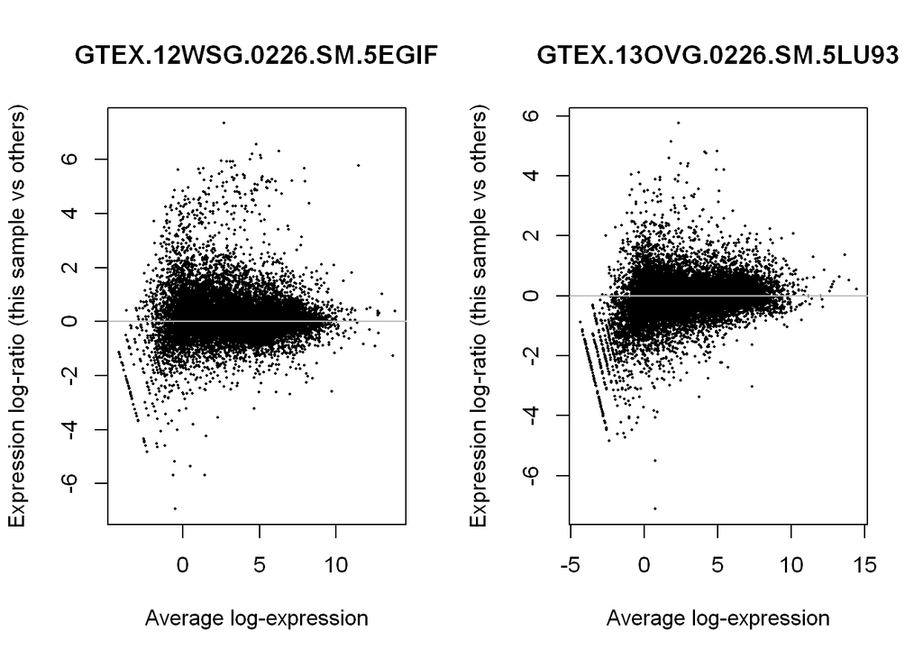

```r
par(mfrow=c(1,2))
plotMD(logcounts,column = 7)
abline(h=0,col="grey")
plotMD(logcounts,column = 11)
abline(h=0,col="grey")
```

Los gráficos de “diferencia de medias”" muestran la expresión promedio (media: eje x) contra los cambios log-fold (diferencia: eje y).

Debido a que nuestro objeto DGEList contiene los factores de normalización, si rehacemos estos gráficos usando y(el objeto y), deberíamos ver que el problema de sesgo de composición (bias composition) ha sido resuelto.

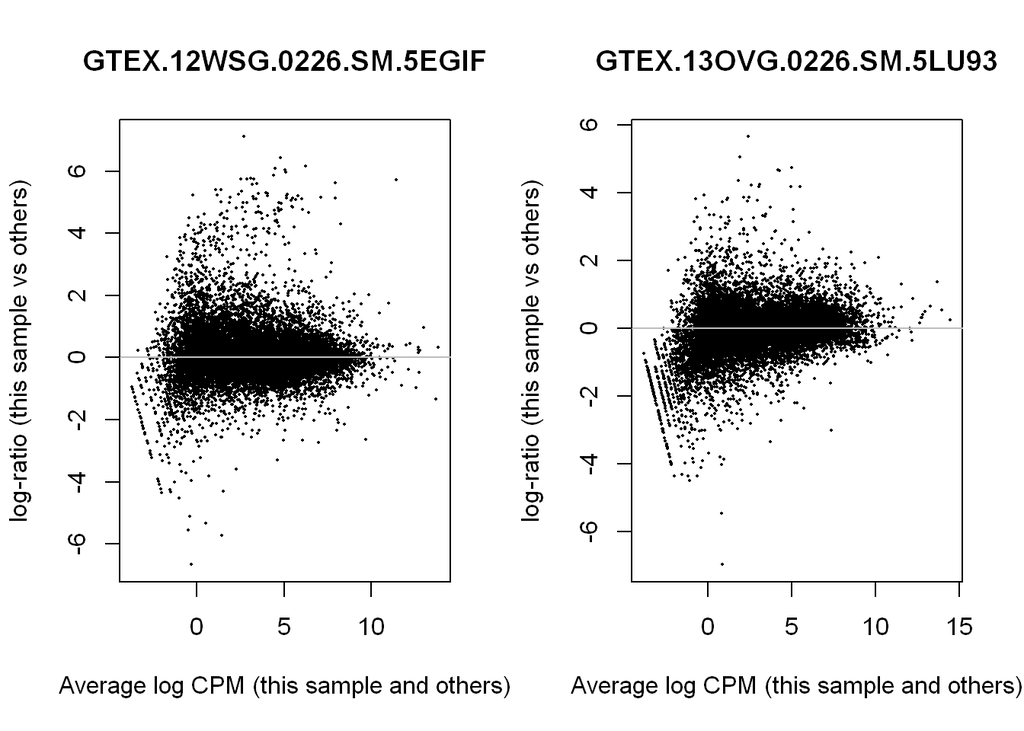

```r
par(mfrow=c(1,2))
plotMD(y,column = 7)
abline(h=0,col="grey")
plotMD(y,column = 11)
abline(h=0,col="grey")
```

.

# Differential expression with limma-voom

Hay una serie de paquetes para analizar datos de RNA-Seq. El paquete limma (Ritchie et al., 2015) (desde la versión 3.16.0) ofrece la función voom, que transforma los recuentos de lectura en logCPM teniendo en cuenta la relación de la media y varianza de los datos (Law et al., 2014).

Después de aplicar voom, los usuarios pueden aplicar un modelo lineal a los datos transformados por voom para identificar genes expresados diferencialmente, utilizando comandos estándar de limma.

Leemos los targets seleccionados y los guardamos en una variable stargets. Despues determinamos los factores y niveles que tenemos. Vemos que nos salen los 3 niveles: SFI, NIT y ELI

```r
stargets<- read.csv2(file.path("./data", "stargets.csv"), head=T, sep=";")
head(stargets,5)
```

```
##   Experiment SRA_Sample              Sample_Name Grupo_analisis body_site
## 1  SRX223301  SRS389914  GTEX-T5JW-1226-SM-3GACY              2   Thyroid
## 2  SRX605452  SRS639261 GTEX-12WSG-0226-SM-5EGIF              2   Thyroid
## 3  SRX559198  SRS624031 GTEX-11O72-2326-SM-5BC7H              2   Thyroid
## 4  SRX614680  SRS644012 GTEX-13O1R-0826-SM-5J2MB              2   Thyroid
## 5  SRX597594  SRS637292  GTEX-ZLV1-0126-SM-4WWBZ              2   Thyroid
##          molecular_data_type    sex Group ShortName
## 1 Allele-Specific Expression female   SFI T5JW-_SFI
## 2              RNA Seq (NGS) female   SFI 12WSG_SFI
## 3              RNA Seq (NGS)   male   SFI 11O72_SFI
## 4              RNA Seq (NGS)   male   SFI 13O1R_SFI
## 5 Allele-Specific Expression female   SFI ZLV1-_SFI
```

```r
group<-factor(stargets$Group)
group
```

```
##  [1] SFI SFI SFI SFI SFI SFI SFI SFI SFI SFI NIT NIT NIT NIT NIT NIT NIT NIT NIT
## [20] NIT ELI ELI ELI ELI ELI ELI ELI ELI ELI ELI
## Levels: ELI NIT SFI
```

## Create the design matrix

Primero, necesitamos crear una matriz de diseño para los grupos (lo teneis como material de consulta la guía del usuario de limma para obtener más información sobre las matrices de diseño y ya fue trabajado en la primera parte del curso).

Hay muchas formas diferentes de configurar la matriz de diseño, y estan supeditadas a las comparaciones que se “quieren testar”. En este análisis, supongamos que queremos testar las diferencias de estado (status) en los diferentes tipos por separado.

Por ejemplo, queremos saber qué genes se expresan diferencialmente

Anteriormente “hemos codificado como variable grupo”, que lleva implicito “cell type and status”.

Codificar de esta manera nos permite ser flexibles al especificar las comparaciones que nos interesan

```r
# Look at group variable again
group
```

```
##  [1] SFI SFI SFI SFI SFI SFI SFI SFI SFI SFI NIT NIT NIT NIT NIT NIT NIT NIT NIT
## [20] NIT ELI ELI ELI ELI ELI ELI ELI ELI ELI ELI
## Levels: ELI NIT SFI
```

```r
# Specify a design matrix without an intercept term
design <- model.matrix(~ 0 + group)
design
```

```
##    groupELI groupNIT groupSFI
## 1         0        0        1
## 2         0        0        1
## 3         0        0        1
## 4         0        0        1
## 5         0        0        1
## 6         0        0        1
## 7         0        0        1
## 8         0        0        1
## 9         0        0        1
## 10        0        0        1
## 11        0        1        0
## 12        0        1        0
## 13        0        1        0
## 14        0        1        0
```

[output cut: 21 more lines]

```r
## Make the column names of the design matrix a bit nicer
colnames(design) <- levels(group)
design
```

```
##    ELI NIT SFI
## 1    0   0   1
## 2    0   0   1
## 3    0   0   1
## 4    0   0   1
## 5    0   0   1
## 6    0   0   1
## 7    0   0   1
## 8    0   0   1
## 9    0   0   1
## 10   0   0   1
## 11   0   1   0
## 12   0   1   0
## 13   0   1   0
## 14   0   1   0
```

[output cut: 21 more lines]

Cada columna de la matriz de diseño nos remite a las muestras que corresponden a cada grupo

voom estima la tendencia de la varianza respecto a la media en el counting data, para luego asignar un peso a cada observación en función de la predicción de la varianza (segun el modelo que nos da la tendencia). Los pesos se usan luego en el proceso de modelado lineal para ajustar la heterocedasticidad.

Asi pués voom ajustará automáticamente los tamaños de biblioteca (library size) utilizando norm.factors ya calculados.

La transformación de voom usa la matriz de diseño de experimento y produce un objeto EList.

Podemos agregar plot = TRUE para generar un gráfico de la tendencia de media-varianza.

Este diagrama es importante ya que nos “informa” de si hay algún gen con “alta variabilidad” en nuestros datos, y sobretodo porque nos indica si hemos filtrado los recuentos bajos adecuadamente.

Los recuentos log2 normalizados que nos aporta voom se pueden encontrar en v$E.

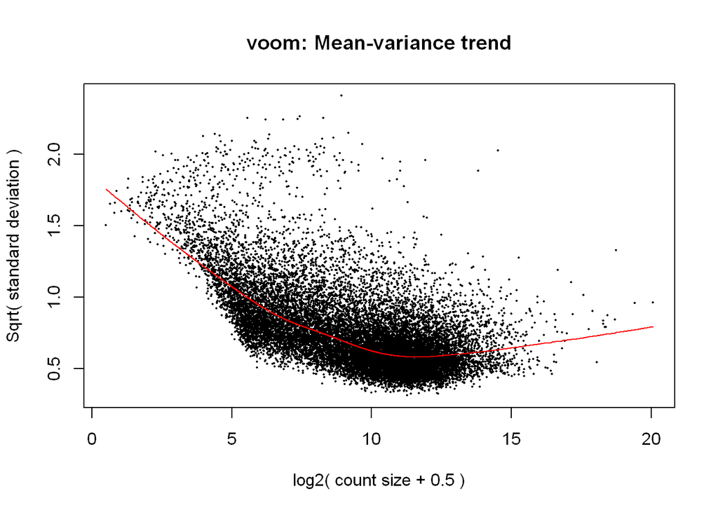

```r
par(mfrow=c(1,1))
v <- voom(y,design,plot = TRUE)
```

```r
v
```

```
## An object of class "EList"
## $targets
##                          group lib.size norm.factors
## GTEX.111VG.0526.SM.5N9BW     1 49051354    0.9417468
## GTEX.11EM3.0126.SM.5985K     1 57429059    0.8841413
## GTEX.11EMC.0226.SM.5EGLP     1 63888030    0.9728161
## GTEX.11NSD.0126.SM.5987F     1 53401129    1.0252789
## GTEX.11NV4.0626.SM.5N9BR     1 57435341    1.1079924
## 25 more rows ...
##
## $E
##                   GTEX.111VG.0526.SM.5N9BW GTEX.11EM3.0126.SM.5985K
## ENSG00000227232.4                3.2740432                 3.543231
## ENSG00000237683.5                3.1235595                 3.784737
## ENSG00000241860.2                0.9151604                 0.254323
## ENSG00000228463.4               -2.3682936                -2.595782
## ENSG00000225972.1                0.8349900                 1.437062
##                   GTEX.11EMC.0226.SM.5EGLP GTEX.11NSD.0126.SM.5987F
## ENSG00000227232.4                3.6218292               2.93539391
## ENSG00000237683.5                3.1149657               3.90595924
## ENSG00000241860.2                0.7507191              -0.85615531
## ENSG00000228463.4               -0.1519837              -0.05229783
## ENSG00000225972.1                0.3688484               1.34335069
##                   GTEX.11NV4.0626.SM.5N9BR GTEX.11O72.2326.SM.5BC7H
## ENSG00000227232.4                4.5020927                3.3590057
## ENSG00000237683.5                4.3014285                4.1225967
## ENSG00000241860.2               -0.3047080                0.4181272
## ENSG00000228463.4                0.6875146               -1.9038009
## ENSG00000225972.1               -1.2892780               -0.1027050
##                   GTEX.12WSG.0226.SM.5EGIF GTEX.139UW.0126.SM.5KM1B
## ENSG00000227232.4                3.1955909                3.2319490
## ENSG00000237683.5                2.5457436                3.8904094
## ENSG00000241860.2               -0.9075749                1.0595084
## ENSG00000228463.4               -2.6333999               -0.7899999
## ENSG00000225972.1                1.3314963                0.2502639
##                   GTEX.13NZ9.1126.SM.5MR37 GTEX.13O1R.0826.SM.5J2MB
## ENSG00000227232.4                3.8350028                3.0426648
## ENSG00000237683.5                3.1004337                2.3223120
## ENSG00000241860.2                0.4580733               -0.4293531
## ENSG00000228463.4               -0.8306030               -1.7599984
```

[output cut: 89 more lines]

```
## [1,] 4.9457510 4.9477069
## [2,] 4.9428488 4.9448032
## [3,] 1.3023259 1.3029452
## [4,] 0.6684714 0.6687823
## [5,] 1.2025686 1.2031545
## 18369 more rows ...
##
## $design
##   ELI NIT SFI
## 1   0   0   1
## 2   0   0   1
## 3   0   0   1
## 4   0   0   1
## 5   0   0   1
## 25 more rows ...
```

Ahora podemos comparar los boxplot despues antes y despues de normalizar. Los valores de expresión en v$E ya son valores en escala logarítmica log2.

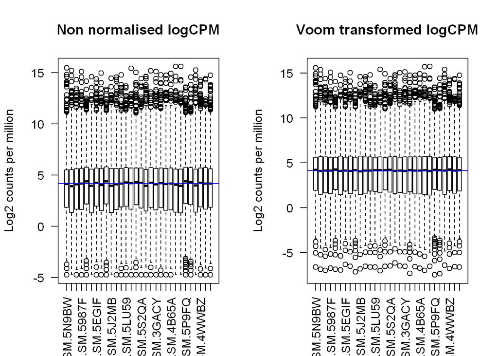

```r
par(mfrow=c(1,2))
boxplot(logcounts, xlab="", ylab="Log2 counts per million",las=2,main="Non normalised logCPM")
## Let's add a blue horizontal line that corresponds to the median logCPM
abline(h=median(logcounts),col="blue")
boxplot(v$E, xlab="", ylab="Log2 counts per million",las=2,main="Voom transformed logCPM")
## Let's add a blue horizontal line that corresponds to the median logCPM
abline(h=median(v$E),col="blue")
```

# Testing for differential expression

Ahora que tenemos los datos obtenidos a partir de la función voom, podemos usar limma para obtener la expresión diferencial. Primero ajustamos un modelo lineal para cada gen usando la función lmFit en limma. lmFit necesita el objeto voom y la matriz de diseño que ya hemos especificado, que se encuentra dentro del objeto generado por voom

```r
# Fit the linear model
fit <- lmFit(v)
names(fit)
```

```
##  [1] "coefficients"     "stdev.unscaled"   "sigma"            "df.residual"
##  [5] "cov.coefficients" "pivot"            "rank"             "Amean"
##  [9] "method"           "design"
```

Hay una serie de elementos dentro del objetofit la mayoría de los cuales, son prácticamente idénticos a los vistos cuando aplicamos dicha función en la primera parte del microarray data analysis.

Dado que estamos interesados en obtener genes diferencialment expresados entre los grupos, debemos especificar qué comparaciones queremos probar.

Las comparaciones se pueden especificar utilizando la función makeContrasts.

Aquí, estamos interesados en saber qué genes se expresan diferencialmente entre los distintos grupos

Los nombres de los grupos deben coincidir exactamente con los nombres de columna de la matriz de diseño.

```r
#cont.matrix <- makeContrasts(SFI-NIT,SFI-ELI,NIT-ELI,levels=design)
cont.matrix <- makeContrasts(SFIvsNIT=SFI-NIT,SFIvsELI=SFI-ELI,NITvsELI=NIT-ELI,levels=design)
cont.matrix
```

```
##       Contrasts
## Levels SFIvsNIT SFIvsELI NITvsELI
##    ELI        0       -1       -1
##    NIT       -1        0        1
##    SFI        1        1        0
```

Las siguientes lineas se corresponden con las ya “presentadas y llevadas a cabo” y que se encuentran dentro del material de la primera parte de la asignatura.

```r
fit.cont <- contrasts.fit(fit, cont.matrix)
fit.cont <- eBayes(fit.cont)
```

```r
summa.fit <- decideTests(fit.cont)
summary(summa.fit)
```

```
##        SFIvsNIT SFIvsELI NITvsELI
## Down          0        0        0
## NotSig    18374    18374    18374
## Up            0        0        0
```

```r
fit.cont
```

```
## An object of class "MArrayLM"
## $coefficients
##                    Contrasts
##                       SFIvsNIT   SFIvsELI   NITvsELI
##   ENSG00000227232.4 -0.1231904 -0.2343738 -0.1111834
##   ENSG00000237683.5 -0.1107212 -0.2871451 -0.1764239
##   ENSG00000241860.2 -0.1806831 -0.3124049 -0.1317218
##   ENSG00000228463.4 -0.9789662 -0.4027514  0.5762148
##   ENSG00000225972.1  1.2761546  0.9660592 -0.3100954
## 18369 more rows ...
##
## $stdev.unscaled
##                    Contrasts
##                      SFIvsNIT  SFIvsELI  NITvsELI
##   ENSG00000227232.4 0.2031788 0.1975970 0.1977131
##   ENSG00000237683.5 0.2052181 0.1983561 0.1991050
##   ENSG00000241860.2 0.4005397 0.3873543 0.3837840
##   ENSG00000228463.4 0.5154630 0.5458204 0.4811301
##   ENSG00000225972.1 0.3825753 0.3540027 0.4108064
## 18369 more rows ...
##
## $sigma
## [1] 1.008990 1.557569 0.629783 1.023444 1.817747
## 18369 more elements ...
##
## $df.residual
## [1] 27 27 27 27 27
## 18369 more elements ...
##
## $cov.coefficients
##           Contrasts
## Contrasts  SFIvsNIT SFIvsELI NITvsELI
##   SFIvsNIT      0.2      0.1     -0.1
##   SFIvsELI      0.1      0.2      0.1
##   NITvsELI     -0.1      0.1      0.2
##
## $rank
## [1] 3
##
## $Amean
```

[output cut: 67 more lines]

```
##                      SFIvsNIT  SFIvsELI  NITvsELI
##   ENSG00000227232.4 -4.687422 -4.562866 -4.883086
##   ENSG00000237683.5 -4.714943 -4.621983 -4.872106
##   ENSG00000241860.2 -4.616419 -4.577709 -4.692876
##   ENSG00000228463.4 -4.541923 -4.605211 -4.570792
##   ENSG00000225972.1 -4.498652 -4.533537 -4.690077
## 18369 more rows ...
##
## $F
## [1] 0.7029646 0.4693886 0.7450031 1.8294749 2.0990762
## 18369 more elements ...
##
## $F.p.value
## [1] 0.5030504 0.6298785 0.4832714 0.1778725 0.1401262
## 18369 more elements ...
```

```r
toptable_SFIvsELI<-topTable(fit.cont,coef="SFIvsELI",sort.by="p")
toptable_SFIvsNIT<-topTable(fit.cont,coef="SFIvsNIT",sort.by="p")
toptable_NITvsELI<-topTable(fit.cont,coef="NITvsELI",sort.by="p")
```

```r
# View(toptable_SFIvsELI)
# View(toptable_SFIvsNIT)
# View(toptable_NITvsELI)
```

# Annotation and saving the results

```r
library(org.Hs.eg.db)
columns(org.Hs.eg.db)
```

```
##  [1] "ACCNUM"       "ALIAS"        "ENSEMBL"      "ENSEMBLPROT"  "ENSEMBLTRANS"
##  [6] "ENTREZID"     "ENZYME"       "EVIDENCE"     "EVIDENCEALL"  "GENENAME"
## [11] "GO"           "GOALL"        "IPI"          "MAP"          "OMIM"
## [16] "ONTOLOGY"     "ONTOLOGYALL"  "PATH"         "PFAM"         "PMID"
## [21] "PROSITE"      "REFSEQ"       "SYMBOL"       "UCSCKG"       "UNIGENE"
## [26] "UNIPROT"
```

No he aconseguit crear les anotacions !

```r
# ann <- select(org.Hs.eg.db,keys=rownames(fit.cont),columns=c("ENTREZID","SYMBOL","GENENAME"))
```

# Volcano Plot

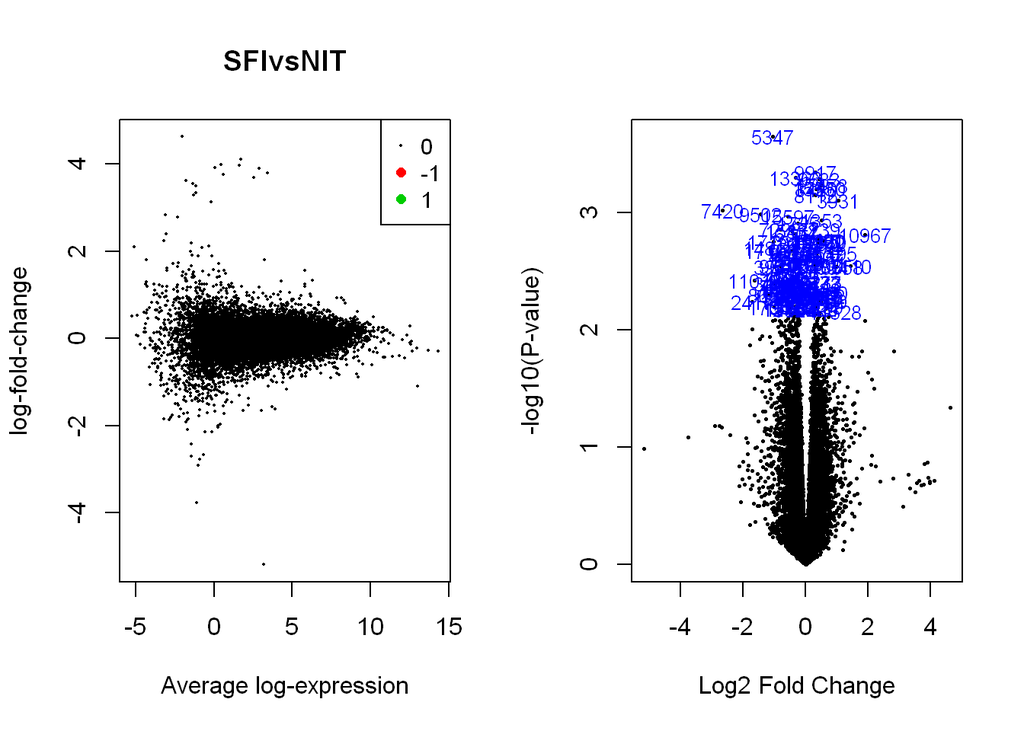

```r
# We want to highlight the significant genes. We can get this from decideTests.
par(mfrow=c(1,2))
plotMD(fit.cont,coef=1,status=summa.fit[,"SFIvsNIT"], values = c(-1, 1))

# For the volcano plot we have to specify how many of the top genes to highlight.
# We can also specify that we want to plot the gene symbol for the highlighted genes.
# let's highlight the top 100 most DE genes
volcanoplot(fit.cont,coef=1,highlight=100,names=fit.cont$genes$SYMBOL)
```

Hay una función llamada treat en el paquete limma (McCarthy y Smyth 2009) que a partir del objeto fit.conty de de un “log fold change (logFC)” determinado por el usuario como “threshold” permite “recalcular the”moderate t-statistics and p-values" . Este procedimiento es mucho más “preciso” “en el control de falsos positivos” que “listar” los p-valores y descartar a continuación genes con logFC pequeños.

```r
# This is easy to do after our analysis, we just give the treat function the fit.cont object and specify our cut-off.
fit.treat <- treat(fit.cont,lfc=1)
res.treat <- decideTests(fit.treat)
summary(res.treat)
```

```
##        SFIvsNIT SFIvsELI NITvsELI
## Down          0        0        0
## NotSig    18374    18374    18374
## Up            0        0        0
```

```r
topTable(fit.treat,coef=1,sort.by="p")
```

```
##                       logFC    AveExpr         t    P.Value adj.P.Val
## ENSG00000170356.8 -2.667071 -0.6691073 -2.285105 0.01476582         1
## ENSG00000225851.1  2.828226 -3.0957945  1.661617 0.05425436         1
## ENSG00000170523.3  1.898064 -0.1426545  1.645973 0.05508328         1
## ENSG00000171195.6  4.624876 -2.0323915  1.630333 0.06515299         1
## ENSG00000160951.3  1.906968 -1.3702753  1.341059 0.09504230         1
## ENSG00000025423.7 -1.651809  3.0560536 -1.237182 0.11279568         1
## ENSG00000175535.6 -3.758024 -1.0910852 -1.319796 0.11344780         1
## ENSG00000253288.1  2.123276 -0.3166287  1.235337 0.11399672         1
## ENSG00000261600.1 -1.707952 -0.4107199 -1.230485 0.11404171         1
## ENSG00000162078.7  2.190884 -1.4227673  1.226245 0.11609204         1
```

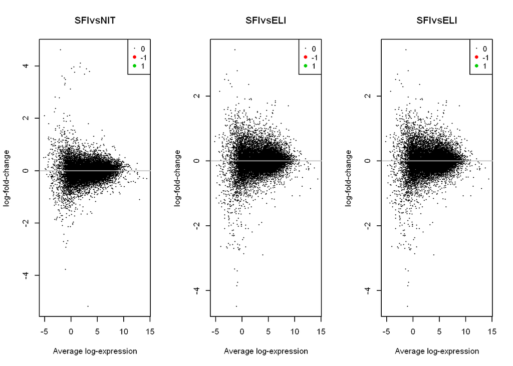

```r
# Notice that much fewer genes are highlighted in the MAplot
par(mfrow=c(1,3))
plotMD(fit.treat,coef=1,status=res.treat[,"SFIvsNIT"], values=c(-1,1))
abline(h=0,col="grey")
plotMD(fit.treat,coef=2,status=res.treat[,"SFIvsELI"], values=c(-1,1))
abline(h=0,col="grey")
plotMD(fit.treat,coef=2,status=res.treat[,"NITvsELI"], values=c(-1,1))
abline(h=0,col="grey")
```

# HeatMap

Finalmente dibujaremos el HeatMap que no se representó en el apartado 12 y quedaba pendiente.

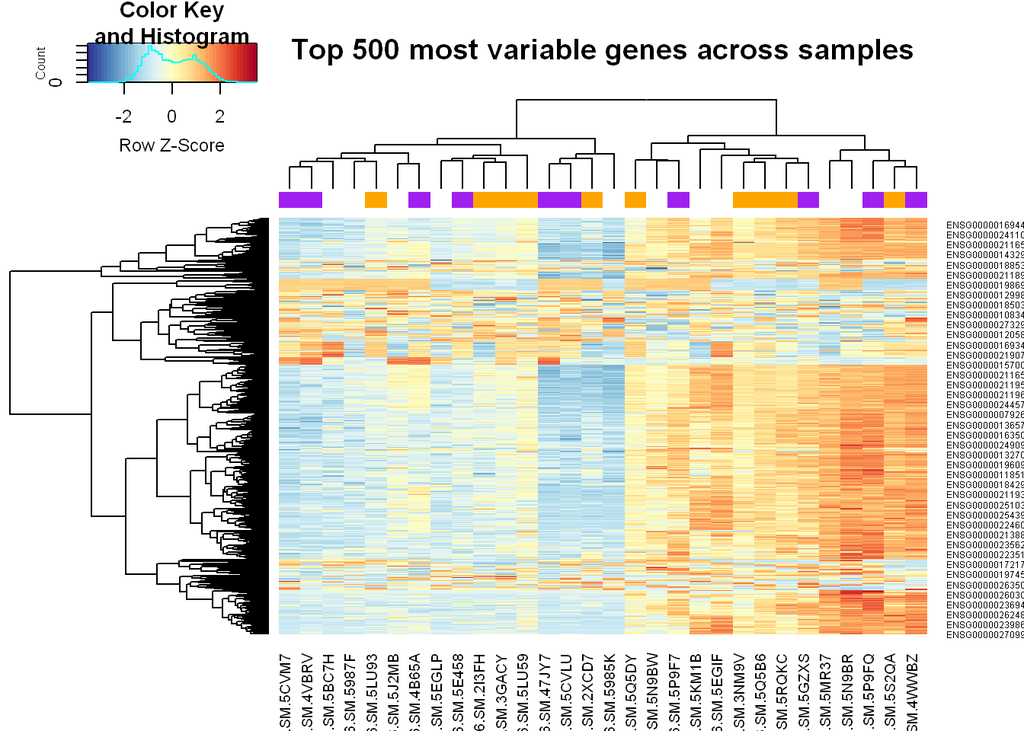

```r
## Get some nicer colours
mypalette <- brewer.pal(11,"RdYlBu")
morecols <- colorRampPalette(mypalette)
# Set up colour vector for celltype variable
col.cell <- c("purple","orange")[stargets$Group]

# Plot the heatmap
par(mfrow=c(1,1))
heatmap.2(highly_variable_lcpm,col=rev(morecols(50)),trace="none", main="Top 500 most variable genes across samples",ColSideColors=col.cell,scale="row")
```

# Referencias:

www.google.com

RNAseqTutorialUOCv2.html

Statistical analysis of RNA-seq data.pdf

IntroToAnnotationPackages.pdf

ENLACE A GitHub:

https://github.com/cmbosch/PAC2